# Explore_bikeshare_data

### Explore Bike Share Data

For this project, your goal is to ask and answer three questions about the available bikeshare data from Washington, Chicago, and New York. This notebook can be submitted directly through the workspace when you are confident in your results.

You will be graded against the project [Rubric](https://review.udacity.com/#!/rubrics/2508/view) by a mentor after you have submitted. To get you started, you can use the template below, but feel free to be creative in your solutions!

```r
library(ggplot2)
library(dplyr)
ny = read.csv('new_york_city.csv')
wash = read.csv('washington.csv')
chi = read.csv('chicago.csv')
head(ny)
summary(ny)
names(ny)
```

| X | Start.Time | End.Time | Trip.Duration | Start.Station | End.Station | User.Type | Gender | Birth.Year |
| --- | --- | --- | --- | --- | --- | --- | --- | --- |
| 5688089 | 2017-06-11 14:55:05 | 2017-06-11 15:08:21 | 795 | Suffolk St & Stanton St | W Broadway & Spring St | Subscriber | Male | 1998 |
| 4096714 | 2017-05-11 15:30:11 | 2017-05-11 15:41:43 | 692 | Lexington Ave & E 63 St | 1 Ave & E 78 St | Subscriber | Male | 1981 |
| 2173887 | 2017-03-29 13:26:26 | 2017-03-29 13:48:31 | 1325 | 1 Pl & Clinton St | Henry St & Degraw St | Subscriber | Male | 1987 |
| 3945638 | 2017-05-08 19:47:18 | 2017-05-08 19:59:01 | 703 | Barrow St & Hudson St | W 20 St & 8 Ave | Subscriber | Female | 1986 |
| 6208972 | 2017-06-21 07:49:16 | 2017-06-21 07:54:46 | 329 | 1 Ave & E 44 St | E 53 St & 3 Ave | Subscriber | Male | 1992 |
| 1285652 | 2017-02-22 18:55:24 | 2017-02-22 19:12:03 | 998 | State St & Smith St | Bond St & Fulton St | Subscriber | Male | 1986 |

```
       X                         Start.Time                   End.Time
 Min.   :     47   2017-05-11 18:26:10:    3   2017-01-03 08:54:10:    2
 1st Qu.:1712425   2017-01-04 13:58:24:    2   2017-01-04 17:21:55:    2
 Median :3418634   2017-01-09 09:36:01:    2   2017-01-05 17:25:17:    2
 Mean   :3415873   2017-01-21 15:36:56:    2   2017-01-12 08:34:01:    2
 3rd Qu.:5123382   2017-01-21 17:49:59:    2   2017-01-12 09:41:54:    2
 Max.   :6816152   2017-01-21 20:08:29:    2   2017-01-12 20:34:42:    2
                   (Other)            :54757   (Other)            :54758
 Trip.Duration                     Start.Station
 Min.   :     61.0   Pershing Square North:  592
 1st Qu.:    368.0   W 21 St & 6 Ave      :  385
 Median :    610.0   Broadway & E 22 St   :  383
 Mean   :    903.6   E 17 St & Broadway   :  380
 3rd Qu.:   1051.0   West St & Chambers St:  364
 Max.   :1088634.0   W 20 St & 11 Ave     :  329
 NA's   :1           (Other)              :52337
                End.Station         User.Type        Gender        Birth.Year
 Pershing Square North:  556             :  119         : 5410   Min.   :1885
 E 17 St & Broadway   :  445   Customer  : 5558   Female:12159   1st Qu.:1970
 Broadway & E 22 St   :  427   Subscriber:49093   Male  :37201   Median :1981
 W 21 St & 6 Ave      :  365                                     Mean   :1978
 W 20 St & 11 Ave     :  344                                     3rd Qu.:1988
 W 38 St & 8 Ave      :  338                                     Max.   :2001
 (Other)              :52295                                     NA's   :5218
```

1. 'X'

2. 'Start.Time'

3. 'End.Time'

4. 'Trip.Duration'

5. 'Start.Station'

6. 'End.Station'

7. 'User.Type'

8. 'Gender'

9. 'Birth.Year'

### Question 1

Does Gender influence the type of rider in New York?

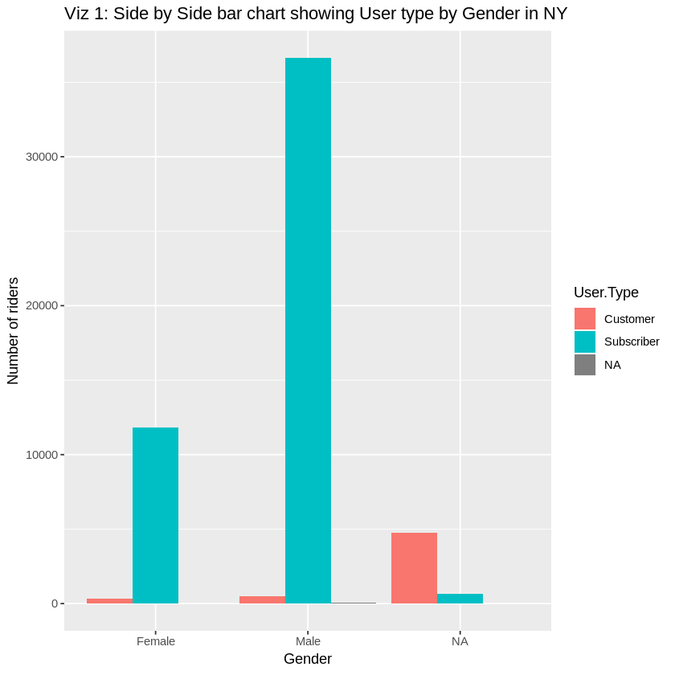

```
               Customer Subscriber
             0        0          0
  Female     0      324      11804
  Male       0      491      36625
```

```
	Pearson's Chi-squared test

data:  ny2$Gender and ny2$User.Type
X-squared = 102.15, df = 1, p-value < 2.2e-16
```

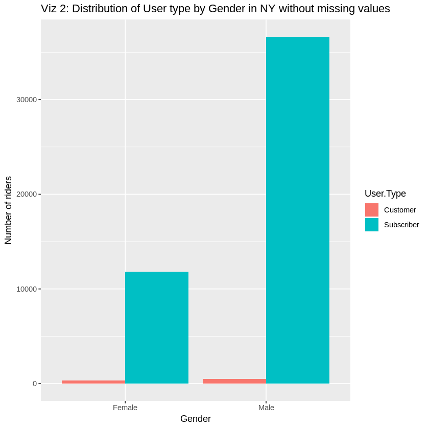

```r
ggplot(ny, aes(x= Gender, fill = User.Type))+
  geom_bar(position = "dodge") +
  ylab('Number of riders')+
  ggtitle('Viz 1: Side by Side bar chart showing User type by Gender in NY')
ny$Gender[ny$Gender==""] <-NA
ny$User.Type[ny$User.Type ==""] <-NA
ny %>%
  filter(!is.na(Gender) & !is.na(User.Type)) %>%
  ggplot(aes(x = Gender, fill = User.Type))+
    geom_bar(position = "dodge") +
    ylab('Number of riders') +
    ggtitle("Viz 2: Distribution of User type by Gender in NY without missing values")
ny2 <-ny %>%
  filter(!is.na(Gender) & !is.na(User.Type))
table(ny2$Gender, ny2$User.Type)
chisq.test(ny2$Gender, ny2$User.Type, correct =FALSE)
```

### Question 2

What is the average travel time for users in different cities?

```r
duration_chi = mean(chi$Trip.Duration)
duration_ny = mean(ny$Trip.Duration)
duration_wash = mean(wash$Trip.Duration)
cat('The average travel time for Chicago is:', duration_chi,'\n')
cat('The average travel time for New York is:', duration_ny,'\n')
cat('The average travel time for Washington is:', duration_wash,'\n')
```

```
The average travel time for Chicago is: 937.1728
The average travel time for New York is: NA
The average travel time for Washington is: NA
```

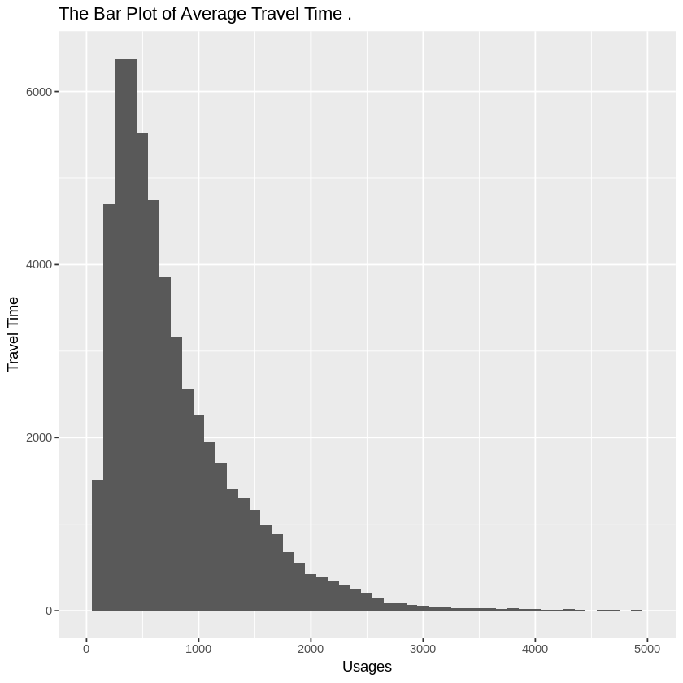

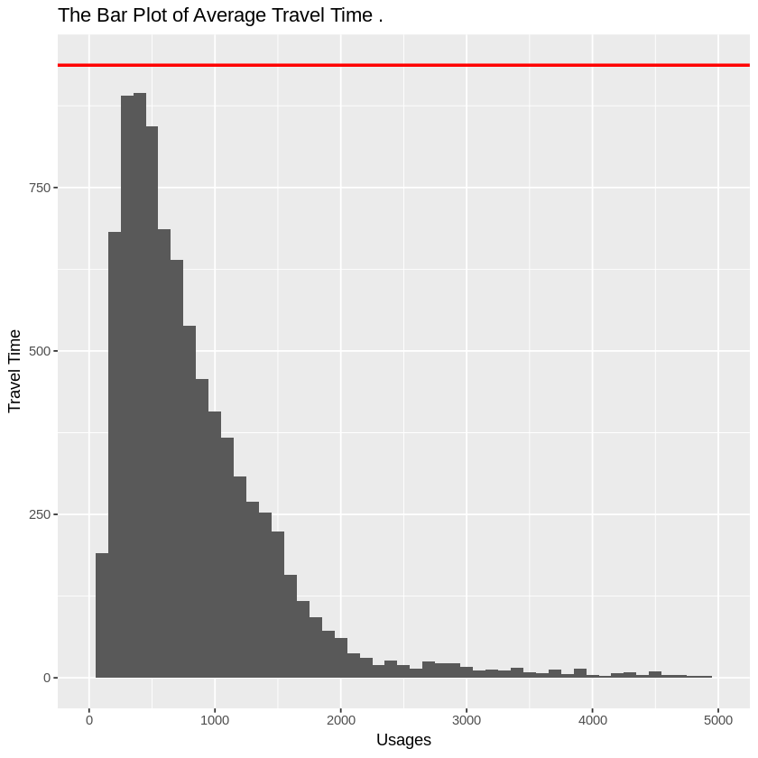

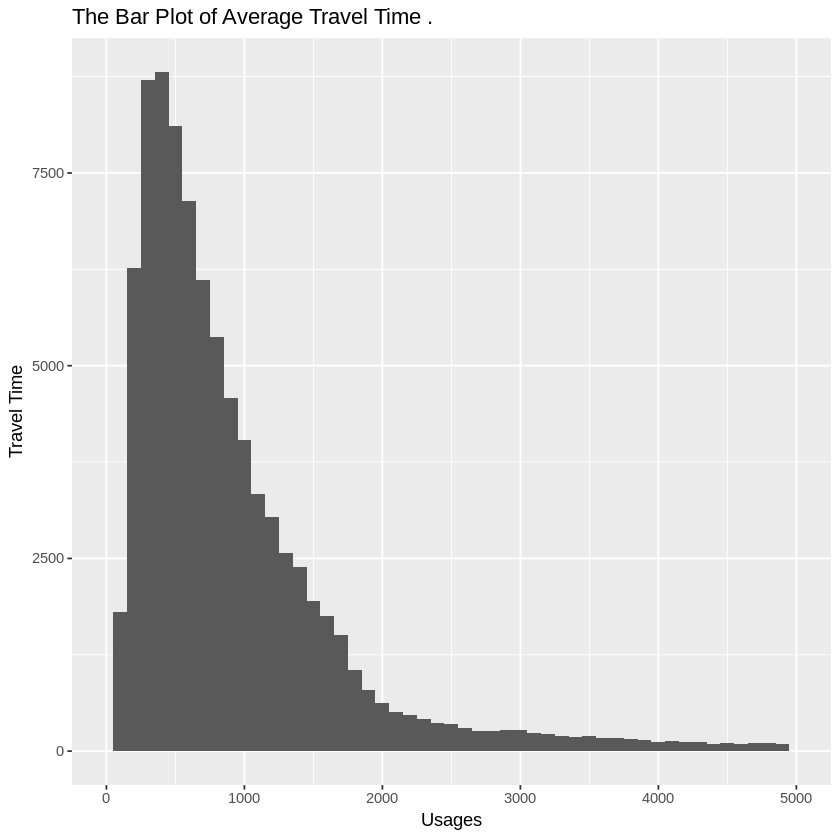

```r
chart <- function(city) {
  var1 <-   ggplot(aes(x=Trip.Duration),data=city)+
            ggtitle("The Bar Plot of Average Travel Time .")+
            geom_histogram(binwidth = 100)+
            scale_x_continuous(limits = c(0,5000))+
            labs(x='Usages',y='Travel Time')+
            geom_hline(aes(yintercept = mean(Trip.Duration)),col='red',size=1)
  return(var1)
}
chart(ny)
chart(chi)
chart(wash)
```

### Question 3

Are male riders younger or older than female in New York in general?

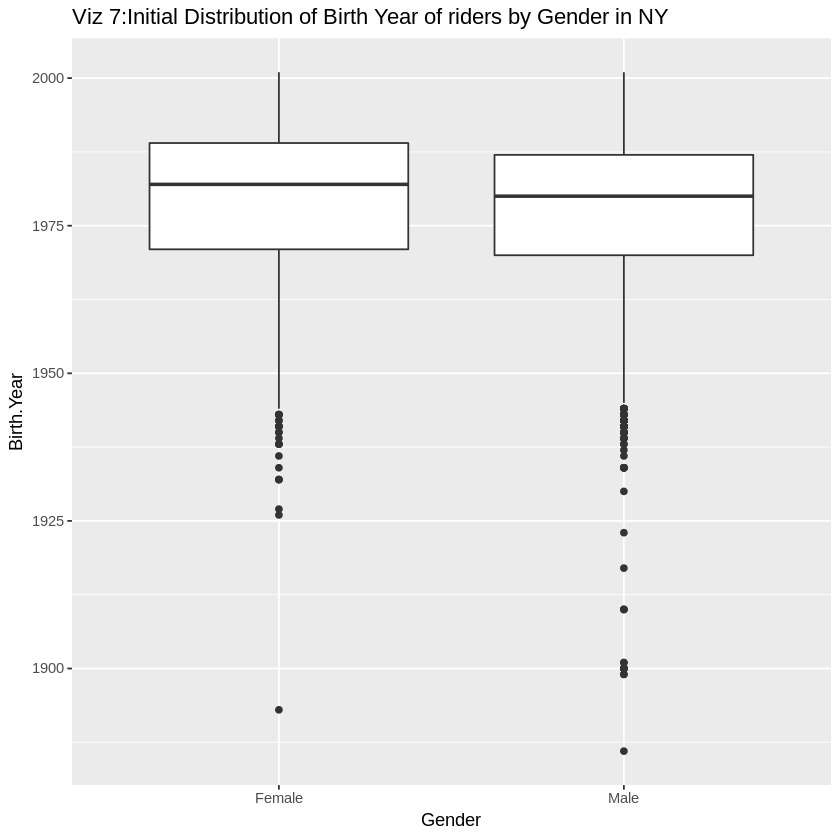

```
ny$Gender:
NULL
------------------------------------------------------------
ny$Gender: Female
   Min. 1st Qu.  Median    Mean 3rd Qu.    Max.    NA's
   1893    1971    1982    1979    1989    2001       1
------------------------------------------------------------
ny$Gender: Male
   Min. 1st Qu.  Median    Mean 3rd Qu.    Max.
   1886    1970    1980    1978    1987    2001
```

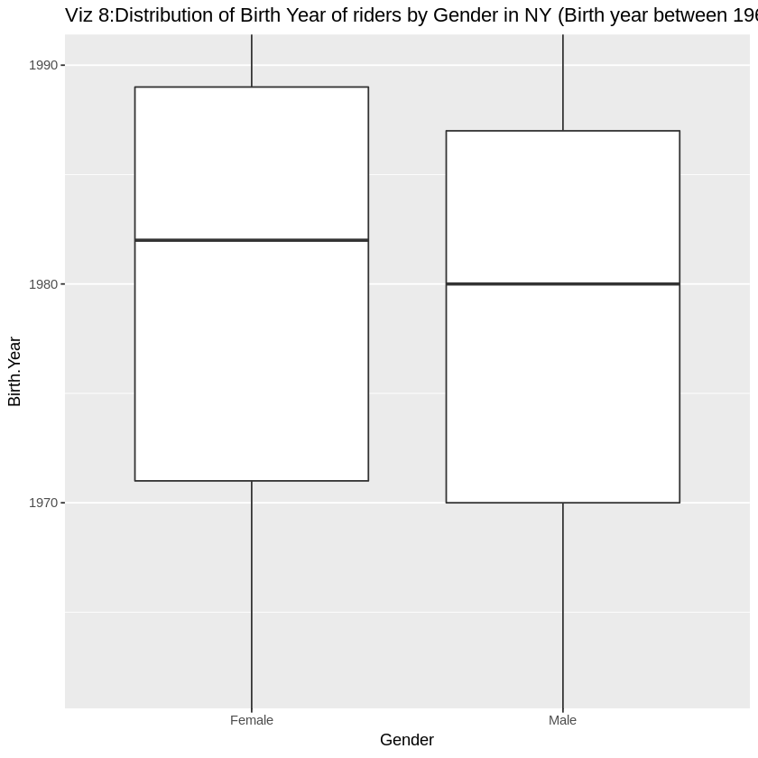

```r
qplot(x = Gender, y = Birth.Year,
  data = subset(ny, !is.na(Gender)),
  geom = 'boxplot') +
  ggtitle('Viz 7:Initial Distribution of Birth Year of riders by Gender in NY')


qplot(x = Gender, y = Birth.Year,
  data = subset(ny, !is.na(Gender)),
  geom = 'boxplot') +
  coord_cartesian(ylim = c(1962,1990))+
  ggtitle('Viz 8:Distribution of Birth Year of riders by Gender in NY (Birth year between 1962 and 1990)')


by(ny$Birth.Year, ny$Gender, summary)
```

The charts explain that males riders are older than females rider as the median no of female riders is 1982 and for male 1980 and the minmum male riders age are 1886 and females are 1893

## Finishing Up

> Congratulations! You have reached the end of the Explore Bikeshare Data Project. You should be very proud of all you have accomplished!

> **Tip**: Once you are satisfied with your work here, check over your report to make sure that it is satisfies all the areas of the [rubric](https://review.udacity.com/#!/rubrics/2508/view).

## Directions to Submit

> Before you submit your project, you need to create a .html or .pdf version of this notebook in the workspace here. To do that, run the code cell below. If it worked correctly, you should get a return code of 0, and you should see the generated .html file in the workspace directory (click on the orange Jupyter icon in the upper left).

> Alternatively, you can download this report as .html via the **File** > **Download as** submenu, and then manually upload it into the workspace directory by clicking on the orange Jupyter icon in the upper left, then using the Upload button.

> Once you've done this, you can submit your project by clicking on the "Submit Project" button in the lower right here. This will create and submit a zip file with this .ipynb doc and the .html or .pdf version you created. Congratulations!

```r
system('python -m nbconvert Explore_bikeshare_data.ipynb')
```